# Dive Into Data Analysis

## Class Pillars:

- Understanding Data
- Looking at Data
- Modeling Data
- Mining Data
- Using Data
- Throughout thr course, will refer to the **OSEMN** data model:
  - Basic workflow used by many data scientists
  - __O__btain
  - __S__crub
  - __E__xplore
  - __M__odel
  - i__N__terpret

## Rough Schedule

| **Topic** | **Day** |
| --- | --- |
| Introduction | 1 |
| Installing Python + Packages | 1 |
| Statistics | 1 |
| Analytics | 2 |
| Graphics | 2-3 |
| Computation | 3 |
| Applications | 3 |
| CAP Overview | 3 |
| Conclusions | 3 |

> **"No plan survives contact with the enemy."** - Helmuth von Moltke the Elder

## Diving into iPython

- This is a presentation driven by iPython.
- Allows me to provide:
- Inline text
- Live Code
- Plotting
- Mathematical Formulae

## We begin by importing the modules we need to use for our topics today

```python
import os
import numpy as np
import urllib
import statsmodels.api as sm
import pandas as pd
import matplotlib.pyplot as plt
import pylab
%matplotlib inline
```

## Overview

- Do First babies arrive late?
- Take a statistical approach
- Get some data
- Load it properly
- Talk about significance

## First Baby Arrivals

- “My two friends that have given birth recently to their first babies, BOTH went almost 2 weeks overdue before going into labor or being induced.”
- “My first one came two weeks late, and now I think this one is coming two weeks early!”
- “I don’t think that can be true because my sister was my mother’s first and she was early, as was many of my cousins.”
- **What’s wrong with these statements?**

## Anecdotal Evidence

- Usually fails because:
- Small number of observations
- Selection bias
- Confirmation bias
- Inaccuracy

**Can we do better?**

## Take A Statistical Approach

- To overcome limitations of anecdotes, use statistical tools. Specifically:
- **Data Collection:** use data from a large national survey designed to generate statistically valid inferences.
- **Descriptive Statistics:** Generate statistics to concisely summarize the data, and then visualize data.
- **Exploratory Data Analysis:** Look for patterns, differences, and other features. Also check for inconsistencies and limitations.
- **Hypothesis testing:** Where there are apparent effects, evaluate whether the effect is real or if it happened by chance.
- **Estimation:** Use data from a sample to estimate characteristics of the general population.

## Get the data:

- In the real world you’ll get data from:
- CSV
- Excel
- APIs
- Scraping
- Database queries

```python
url2002FemPreg = "ftp://ftp.cdc.gov/pub/Health_Statistics/NCHS/Datasets/NSFG/2002FemPreg.dat"

local2002FemPreg = "2002FemPreg.dat"

os.chdir("/Users/damian/Documents/Dropbox/Lake-Hill-Analytics/Business/Clients/ASPE/Intermediate Data Analysis Bootcamp/Class Materials/sourcedata")

try:
    urllib.urlretrieve(url2002FemPreg, local2002FemPreg)
    print "Successfully grabbed pregnancy files"
except:
    print "Failed to grab files"
```

```
Successfully grabbed pregnancy files
```

```python
pregColSpecs = [
            (1, 12),
            (22, 23),
            (56, 57),
            (57, 58),
            (59, 60),
            (275, 276),
            (277, 278),
            (278, 279),
            (284, 287),
            (423, 440)
            ]

pregColNames = [
            'caseid',
            'nbrnaliv',
            'babysex',
            'birthwgt_lb',
            'birthwgt_oz',
            'prglength',
            'outcome',
            'birthord',
            'agepreg',
            'finalwgt'
            ]

df2002Preg = pd.read_fwf(local2002FemPreg, colspecs=pregColSpecs, header=None)
df2002Preg.columns = pregColNames
#df2002Preg.drop(['nbrnaliv', 'babysex', 'outcome'], axis=1, inplace=True)
df2002Preg.describe()
```

|  | caseid | nbrnaliv | babysex | birthwgt_lb | birthwgt_oz | prglength | outcome | birthord | agepreg | finalwgt |
| --- | --- | --- | --- | --- | --- | --- | --- | --- | --- | --- |
| count | 13593.000000 | 163.000000 | 235.000000 | 9144.000000 | 9087.000000 | 13593.000000 | 1 | 9148.000000 | 13241.000000 | 13593.000000 |
| mean | 6216.526595 | 1.834356 | 3.025532 | 6.653762 | 3.707384 | 5.882292 | 1 | 1.824552 | 503.102560 | 5645.602005 |
| std | 3645.417341 | 1.630208 | 3.476322 | 1.588809 | 2.813151 | 3.350894 | NaN | 1.037053 | 300.039668 | 8506.962857 |
| min | 1.000000 | 1.000000 | 1.000000 | 0.000000 | 0.000000 | 0.000000 | 1 | 0.000000 | 0.000000 | 0.292177 |
| 25% | 3022.000000 | 1.000000 | 1.000000 | 6.000000 | 1.000000 | 3.000000 | 1 | 1.000000 | 233.000000 | 1399.312475 |
| 50% | 6161.000000 | 1.000000 | 1.000000 | 7.000000 | 3.000000 | 7.000000 | 1 | 2.000000 | 516.000000 | 4905.409612 |
| 75% | 9423.000000 | 1.000000 | 7.000000 | 8.000000 | 6.000000 | 9.000000 | 1 | 2.000000 | 775.000000 | 7160.450747 |
| max | 12571.000000 | 5.000000 | 9.000000 | 9.000000 | 9.000000 | 9.000000 | 1 | 9.000000 | 991.000000 | 261879.953864 |

```python
# Let's do a quick check on average length of first pregnancies vs. later pregnancies
df2002Preg.fillna(0, inplace=True)
avgFirstLength = df2002Preg[df2002Preg['birthord'] == 1].prglength.mean()
avgOtherLength = df2002Preg[df2002Preg['birthord'] > 1].prglength.mean()

print "First Pregnancy Length (average): " + str(avgFirstLength)
print "Later Pregnancy Length (average): " + str(avgOtherLength)
print "Delta: " + str(abs(avgFirstLength - avgOtherLength))
```

```
First Pregnancy Length (average): 5.98821663268
Later Pregnancy Length (average): 6.49978876215
Delta: 0.51157212947
```

## What insights so far?

- Answers from **Think Stats**:
- First babies are born about 13 hours later than subsequent babies.
- That’s an **apparent effect**: but we need to determine if it’s real
  - If the groups have different means, what about the other **summary statistics** like median and variance. Can we be more precise about how the groups differ?
  - The difference we saw could have happened by chance. If that’s the case we’d say that the effect is not **statistically significant**.
  - Finally - is the apparent effect due to selection bias or experimental error? If so then it’s an **artifact** that we created.
- Our problem:
- Using Pandas, the field coding is inaccurate and doesn't load properly
- Survey [codebook](http://nsfg.icpsr.umich.edu/cocoon/WebDocs/NSFG/public/index.htm) returns a 404 error.
  - Unable to quickly verify the coding
- **Welcome to true data analysis!**

# First Exercise

- Think about questions that you find personally interesting, conventional wisdom, controversial topics, or political questions.
- Try to formulate a question that lends itself to statistical inquiry
- Look for data to help:
- Governments have a lot of free data.
- Wolfram Alpha has a collection: www.wolframalpha.com
- Once you’ve done that, prepare to discuss your topic with the class.

## Summary Statistics

- **Mean:** a mathematically derived description of the sum of all values divided by the number of values. $\begin{equation} AM = \frac{1}{n}\sum_{i=1}^na_i = \frac{1}{n}\left(a_1 + a_2 + \cdots + a_n\right) \end{equation}$
- **Variance:** the expected value of the squared deviation. $\operatorname{Var}(X) = \operatorname{E}\left[(X - \mu)^2 \right]$
- **Standard Deviation:** Square root of the variance. $s^2_N = \frac{1}{N} \sum_{i=1}^N (x_i - \overline{x})^2$

## American National Election Survey 1996 Data

- Public domain data available in the statsmodels package
- Information
- Number of observations - 944
- Number of variables - 10
- Variables name definitions:
  - **popul** Census place population in 1000s
  - **TVnews** Number of times per week that respondent watches TV news.
  - **PID** Party identification of respondent.
  - 0 - Strong Democrat
  - 1 - Weak Democrat
  - 2 - Independent-Democrat
  - 3 - Independent-Indpendent
  - 4 - Independent-Republican
  - 5 - Weak Republican
  - 6 - Strong Republican
  - **age** Age of respondent.
  - **educ** Education level of respondent
  - 1 - 1-8 grades
  - 2 - Some high school
  - 3 - High school graduate
  - 4 - Some college
  - 5 - College degree
  - 6 - Master's degree
  - 7 - PhD
  - **income** - Income of household
  - 1 - None or less than 2,999
  - 2 - 3,000-4,999
  - 3 - 5,000-6,999
  - 4 - 7,000-8,999
  - 5 - 9,000-9,999
  - 6 - 10,000-10,999
  - 7 - 11,000-11,999
  - 8 - 12,000-12,999
  - 9 - 13,000-13,999
  - 10 - 14,000-14.999
  - 11 - 15,000-16,999
  - 12 - 17,000-19,999
  - 13 - 20,000-21,999
  - 14 - 22,000-24,999
  - 15 - 25,000-29,999
  - 16 - 30,000-34,999
  - 17 - 35,000-39,999
  - 18 - 40,000-44,999
  - 19 - 45,000-49,999
  - 20 - 50,000-59,999
  - 21 - 60,000-74,999
  - 22 - 75,000-89,999
  - 23 - 90,000-104,999
  - 24 - 105,000 and over
  - **vote** Expected vote
  - 0 - Clinton
  - 1 - Dole
  - The following 3 variables all take the values:
  - 1 - Extremely liberal
  - 2 - Liberal
  - 3 - Slightly liberal
  - 4 - Moderate
  - 5 - Slightly conservative
  - 6 - Conservative
  - 7 - Extremely Conservative
  - **selfLR** Respondent's self-reported political leanings from "Left" to "Right".
  - **ClinLR** - Respondents impression of Bill Clinton's political leanings from "Left" to "Right".
  - **DoleLR** - Respondents impression of Bob Dole's political leanings from "Left" to "Right".
  - **logpopul** - log(popul + .1)

```python
data = sm.datasets.anes96.load_pandas()
dfElections = data.data
```

```python
# Describe the entire dataset
dfElections.describe()
```

|  | popul | TVnews | selfLR | ClinLR | DoleLR | PID | age | educ | income | vote | logpopul |
| --- | --- | --- | --- | --- | --- | --- | --- | --- | --- | --- | --- |
| count | 944.000000 | 944.000000 | 944.000000 | 944.000000 | 944.000000 | 944.000000 | 944.000000 | 944.000000 | 944.000000 | 944.000000 | 944.000000 |
| mean | 306.381356 | 3.727754 | 4.325212 | 2.939619 | 5.394068 | 2.842161 | 47.043432 | 4.565678 | 16.331568 | 0.416314 | 2.472307 |
| std | 1082.606745 | 2.677235 | 1.438436 | 1.383725 | 1.269349 | 2.273337 | 16.423130 | 1.599287 | 5.974781 | 0.493208 | 3.187043 |
| min | 0.000000 | 0.000000 | 1.000000 | 1.000000 | 1.000000 | 0.000000 | 19.000000 | 1.000000 | 1.000000 | 0.000000 | -2.302585 |
| 25% | 1.000000 | 1.000000 | 3.000000 | 2.000000 | 5.000000 | 1.000000 | 34.000000 | 3.000000 | 14.000000 | 0.000000 | 0.095310 |
| 50% | 22.000000 | 3.000000 | 4.000000 | 3.000000 | 6.000000 | 2.000000 | 44.000000 | 4.000000 | 17.000000 | 0.000000 | 3.095578 |
| 75% | 110.000000 | 7.000000 | 6.000000 | 4.000000 | 6.000000 | 5.000000 | 58.000000 | 6.000000 | 21.000000 | 1.000000 | 4.701389 |
| max | 7300.000000 | 7.000000 | 7.000000 | 7.000000 | 7.000000 | 6.000000 | 91.000000 | 7.000000 | 24.000000 | 1.000000 | 8.895643 |

```python
# Examine a slice of the dataset
dfElections.head()
```

|  | popul | TVnews | selfLR | ClinLR | DoleLR | PID | age | educ | income | vote | logpopul |
| --- | --- | --- | --- | --- | --- | --- | --- | --- | --- | --- | --- |
| 0 | 0 | 7 | 7 | 1 | 6 | 6 | 36 | 3 | 1 | 1 | -2.302585 |
| 1 | 190 | 1 | 3 | 3 | 5 | 1 | 20 | 4 | 1 | 0 | 5.247550 |
| 2 | 31 | 7 | 2 | 2 | 6 | 1 | 24 | 6 | 1 | 0 | 3.437208 |
| 3 | 83 | 4 | 3 | 4 | 5 | 1 | 28 | 6 | 1 | 0 | 4.420045 |
| 4 | 640 | 7 | 5 | 6 | 4 | 0 | 68 | 6 | 1 | 0 | 6.461624 |

```python
# Describe only the age column
dfElections.age.describe()
```

```
count    944.000000
mean      47.043432
std       16.423130
min       19.000000
25%       34.000000
50%       44.000000
75%       58.000000
max       91.000000
Name: age, dtype: float64
```

```python
# Show the variance of the age column
print "Variance of Age: " + str(dfElections.age.var())
```

```
Variance of Age: 269.719214507
```

## Distributions

- Distributions describe how often each value appears.
- **Frequency**: the number of times a value appears in a dataset.
- **Probability**: a frequency expressed as a fraction of the sample size
- **Mode**: the most frequent value in the dataset.

```python
# Let's make a label array
binValue = ["None or less than 2,999", "3,000-4,999","5,000-6,999","7,000-8,999","9,000-9,999","10,000-10,999","11,000-11,999"
            ,"12,000-12,999","13,000-13,999","14,000-14.999","15,000-16,999","17,000-19,999","20,000-21,999","22,000-24,999"
            ,"25,000-29,999","30,000-34,999","35,000-39,999","40,000-44,999","45,000-49,999","50,000-59,999","60,000-74,999"
            ,"75,000-89,999","90,000-104,999","105,000 and over"]
```

```python
# Let's understand the distribution of income now.
dfIncomeDist = pd.DataFrame(dfElections.income.value_counts(), columns=['Frequency'])
dfIncomeDist['Probability'] = dfIncomeDist['Frequency'] / dfIncomeDist.Frequency.sum()
dfIncomeDist.sort_index(inplace=True)
dfIncomeDist
```

|  | Frequency | Probability |
| --- | --- | --- |
| 1 | 19 | 0.020127 |
| 2 | 12 | 0.012712 |
| 3 | 17 | 0.018008 |
| 4 | 19 | 0.020127 |
| 5 | 18 | 0.019068 |
| 6 | 13 | 0.013771 |
| 7 | 11 | 0.011653 |
| 8 | 17 | 0.018008 |
| 9 | 10 | 0.010593 |
| 10 | 15 | 0.015890 |
| 11 | 23 | 0.024364 |
| 12 | 35 | 0.037076 |
| 13 | 26 | 0.027542 |
| 14 | 39 | 0.041314 |
| 15 | 68 | 0.072034 |
| 16 | 70 | 0.074153 |
| 17 | 62 | 0.065678 |
| 18 | 48 | 0.050847 |
| 19 | 51 | 0.054025 |
| 20 | 100 | 0.105932 |
| 21 | 103 | 0.109110 |
| 22 | 53 | 0.056144 |
| 23 | 47 | 0.049788 |
| 24 | 68 | 0.072034 |

```python
print "Income Mode (bin number): " + str(dfIncomeDist[dfIncomeDist['Frequency'] == dfIncomeDist.Frequency.max()].index.tolist()[0])

print "Income Mode (income range): " + binValue[int(dfIncomeDist[dfIncomeDist['Frequency'] == dfIncomeDist.Frequency.max()].index.tolist()[0]) - 1]
```

```
Income Mode (bin number): 21.0
Income Mode (income range): 60,000-74,999
```

# Histograms

- A useful plot that allows users to quickly:
- Find the mode
- Understand the shape of the data
- Identify outliers
- Not ideal for comparing multiple distributions

### Let's plot the histogram of income.

- We use the original dataset for this.

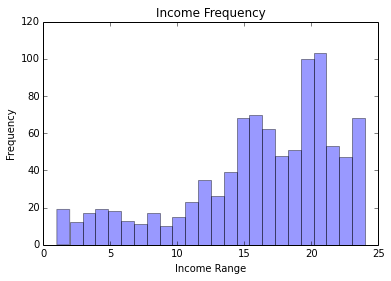

```python
plt.hist(dfElections.income, bins=24, alpha=0.4)
plt.title('Income Frequency')
plt.xlabel('Income Range')
plt.ylabel('Frequency')
plt.show()
```

### Let's plot the histogram of age

- again, original data set

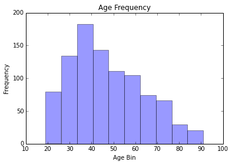

```python
plt.hist(dfElections.age, alpha=0.4)
plt.title('Age Frequency')
plt.xlabel('Age Bin')
plt.ylabel('Frequency')
plt.show()
```

```python
# What is the mode of the age column?
print "mode (age): " +  str(dfElections.age.mode())
print "median (age): " + str(dfElections.age.median())
print "mean (age): "  + str(dfElections.age.mean())
```

```
mode (age): 0    35
dtype: float64
median (age): 44.0
mean (age): 47.0434322034
```

```python
# What is the mode of the income column?
print "mode (income): " +  str(dfElections.income.mode())
print "median (income): " + str(dfElections.income.median())
print "mean (income): "  + str(dfElections.income.mean())
```

```
mode (income): 0    21
dtype: float64
median (income): 17.0
mean (income): 16.3315677966
```

# Cumulative Distribution Functions

- Percentiles
- Cumulative Distribution Functions

## Percentiles

- Defined as the value at which that percentage of the population is below you.
- Go back to the age of voters in our Election data

```python
dfElections.age.describe()
```

```
count    944.000000
mean      47.043432
std       16.423130
min       19.000000
25%       34.000000
50%       44.000000
75%       58.000000
max       91.000000
Name: age, dtype: float64
```

- In the age column:
  - **25%** of the population is 34 years old or younger
  - **50%** of the population is 44 or younger.
  - **75%** of the population is 58 or younger.
- What if we want the 95th percentile?
  - Use the **quantile** function.

```python
dfElections.age.quantile(.95)
```

```
77.0
```

## The Cumulative Distribution Function

- The cumulative distribution function of a real-valued random variable $''X''$ is the function given by:

$F_X(x) = \operatorname{P}(X\leq x)$

- Where the right-hand side represents the probability that the random variable $''X''$ takes on a value less than or equal to $''x''$.

# Representing Cumulative Distribution Functions

- Again, use the age data from the election dataset
- Conditional Distributions

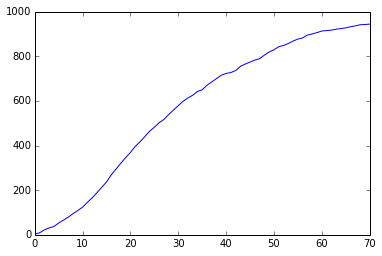

```python
dfAgeDist = pd.DataFrame(dfElections.age.value_counts(), columns=['Frequency'])
dfAgeDist.sort_index(inplace=True)
dfAgeDist['CumulativeSum'] = dfAgeDist.Frequency.cumsum()
cdfAgeDist = plt.plot(dfAgeDist.CumulativeSum)
```

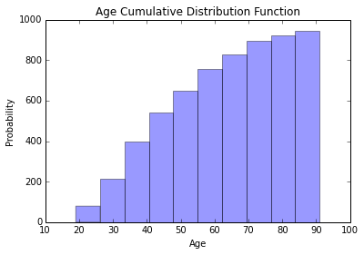

```python
plt.hist(dfElections.age, alpha=0.4, cumulative=True)
plt.title('Age Cumulative Distribution Function')
plt.xlabel('Age')
plt.ylabel('Probability')
plt.show()
```

# Continuous Distributions

- The Exponential Distribution
- The Pareto Distribution
- The Normal Distribution
- Normal Probability Plot
- Why Model?

### The Exponential Distribution

- The probability distribution that describes the time between events in a process in which events occur continuously and independently at a constant average rate.
- Description on Wikipedia: https://en.wikipedia.org/wiki/Exponential_distribution

### The Pareto Distribution

- The Pareto distribution, named after the Italian civil engineer, economist, and sociologist Vilfredo Pareto, is a power law probability distribution that is used in description of social, scientific, geophysical, actuarial, and many other types of observable phenomena.
- Description on Wikipedia: https://en.wikipedia.org/wiki/Pareto_distribution

## The Normal Distribution

- In probability theory, the **normal** (or **Gaussian**) distribution is a very commonly occurring continuous probability distribution — a function that tells the probability that any real observation will fall between any two real limits or real numbers, as the curve approaches zero on either side.
- Normal distributions are extremely important in statistics and are often used in the natural sciences and social sciences for real-valued random variables whose distributions are not known.
- Description on Wikipedia: https://en.wikipedia.org/wiki/Normal_distribution
- Plot a normal distribution from random data:

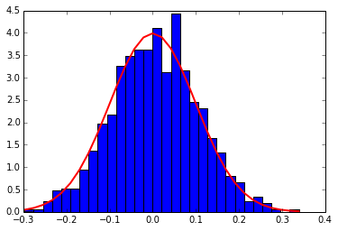

```python
mu, sigma = 0, 0.1 # mean and standard deviation
s = np.random.normal(mu, sigma, 1000)
count, bins, ignored = plt.hist(s, 30, normed=True)
plt.plot(bins, 1/(sigma * np.sqrt(2 * np.pi)) * np.exp( - (bins - mu)**2 / (2 * sigma**2) ),linewidth=2, color='r')
plt.show()
```

```python
# What is the mode / median / mean of the random distribuion?
randomSeries = pd.DataFrame(s)
print "mode (age): " +  str(randomSeries.mode())
print "median (age): " + str(randomSeries.median())
print "mean (age): "  + str(randomSeries.mean())
```

```
mode (age): Empty DataFrame
Columns: [0]
Index: []
median (age): 0    0.007036
dtype: float64
mean (age): 0    0.005541
dtype: float64
```

## The Normal Probability Plot

- A graphical technique to identify substantive departures from the normal distribution. This includes identifying outliers, skewness, kurtosis, a need for transformations, and Mixture distribution.
- Normal probability plots are made of raw data, residuals from model fits, and estimated parameters.
- In a normal probability plot (also called a "normal plot"), the sorted data are plotted vs. values selected to make the resulting image look close to a straight line if the data are approximately normally distributed. Deviations from a straight line suggest departures from normality.

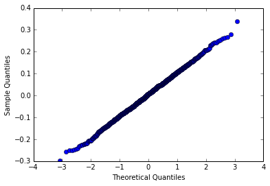

```python
sm.qqplot(s)
pylab.show()
```

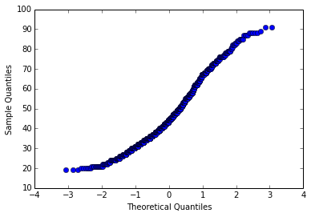

```python
sm.qqplot(dfElections.age)
pylab.show()
```

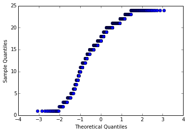

```python
sm.qqplot(dfElections.income)
pylab.show()
```

# Probability

- Rules of Probability
- Monty Hall
- Monte Carlo
- Bayes’s Theorem

## Rules of Probability

- **Sample Space**: the collection of all results.
- **Power Set**: All collections of possible results.
- Ex: A dice may have six possible results. The subset {1,3,5} is an element of the power set of the sample space.
- These are **events**.
- The above event is the event that the dice falls on an odd number.
- Probability assigns each event a value between zeor and one. The event made up of all possible results is assigned 1.
- The probability of an event A is written as $P(A)$, $p(A)$ or $Pr(A)$. This mathematical definition of probability can extend to infinite sample spaces, and even uncountable sample spaces, using the concept of a measure.
- The opposite or complement of an event A is the event [not A] (that is, the event of A not occurring); its probability is given by $P(not A) = 1 − P(A)$.
- As an example, the chance of not rolling a six on a six-sided die is $1 – (chance of rolling a six) = 1 - \tfrac{1}{6} = \tfrac{5}{6}$.
- If two events A and B occur on a single performance of an experiment, this is called the intersection or joint probability of A and B, denoted as $P(A \cap B)$.
- **Independent events**:
- If two events, A and B are independent then the joint probability is
- $P(A \mbox{ and }B) = P(A \cap B) = P(A) P(B)$, for example, if two coins are flipped the chance of both being heads is $\tfrac{1}{2}\times\tfrac{1}{2} = \tfrac{1}{4}$.
- **Mutually exclusive events**:
- If either event A or event B or both events occur on a single performance of an experiment this is called the union of the events A and B denoted as $P(A \cup B)$.
- If two events are mutually exclusive then the probability of either occurring is $P(A\mbox{ or }B) = P(A \cup B)= P(A) + P(B)$.
- For example, the chance of rolling a 1 or 2 on a six-sided die is $P(1\mbox{ or }2) = P(1) + P(2) = \tfrac{1}{6} + \tfrac{1}{6} = \tfrac{1}{3}$.
- **Not mutually exclusive events**:
- If the events are not mutually exclusive then $P\left(A \hbox{ or } B\right)=P\left(A\right)+P\left(B\right)-P\left(A \mbox{ and } B\right)$.
- For example, when drawing a single card at random from a regular deck of cards, the chance of getting a heart or a face card (J,Q,K) (or one that is both) is $\tfrac{13}{52} + \tfrac{12}{52} - \tfrac{3}{52} = \tfrac{11}{26}$, because of the 52 cards of a deck 13 are hearts, 12 are face cards, and 3 are both: here the possibilities included in the "3 that are both" are included in each of the "13 hearts" and the "12 face cards" but should only be counted once.

## Monty Hall Problem:

- On *Let's Make a Deal*, the host Monty Hall shows you three closed doors and tells you that there is a prize behind each door: one prize is a car, the other two are less valuable prizes like peanut butter and fake fingernails. The prizes are arranged at random.
- The object of the game is to guess which door has the car. If you guess right, you get to keep the car.
- So you pick a door, which we will call Door A. We’ll call the other doors B and C.
- Before opening the door you chose, Monty likes to increase the suspense by opening either Door B or C, whichever does not have the car.
- If the car is actually behind Door A, Monty can safely open B or C, so he chooses one at random.
- Then Monty offers you the option to stick with your original choice or switch to the one remaining unopened door.

### Should you switch your choice, or should you stick with your original?

- Intuition: It doesn't make a difference

### Let's simulate it to find out

```python
import random # We need the random module to select integers in [1,3] randomly


def pick_door():
    """
    Function to pick a door. Returns an integer 1, 2, or 3 at random.
    """
    return random.randint(1,3)


class MontyHall:
    """
    Class to model the Monty Hall problem.
    """
    def __init__(self):
        """
        Creates an instance of the Monty Hall problem. This will be called
        automatically when the class is formed.
        """
        # Pick a prize door randomly and store as a variable.
        self.prize_door = pick_door()
        # We'll create variables for the selected door and removed door as
        # well, but we won't set them just yet.
        self.selected_door = None
        self.removed_door = None

    def select_door(self):
        """
        Randomly selects a door for the contestant.
        """
        self.selected_door = pick_door()

    def remove_door(self):
        """
        This is how the host removes a (non-prize/non-selected) door..
        """
        # Pick a door at random.
        d = pick_door()
        # If that door is the prize door or the contestant's door, re-pick.
        while d == self.selected_door or d == self.prize_door:
            d = pick_door()
        # set the removed door to d
        self.removed_door = d

    def switch_choice(self):
        """
        Switches the selected door once a non-prize door is removed.
        """
        # 1+2+3=6. There's only one choice of door if we switch our selection.
        self.selected_door = 6 - self.selected_door - self.removed_door

    def user_wins(self):
        """
        Determine if the user wins. Return true on win, false on lose.
        """
        if self.selected_door == self.prize_door:
            return True
        else:
            return False

    def run_game(self, switch=True):
        """
        Once a problem is initialized, run the game.

        'switch' determines if the user changes selection during the game.
        """
        # The user selects a door.
        self.select_door()
        # The host removes a door.
        self.remove_door()
        # The user can switch selection of doors.
        if switch:
            self.switch_choice()
        # Determine if the user wins.
        return self.user_wins()



# Now, we'll run the game. When asked if we want to switch door selection when
# the door is removed by the host, we'll say 'yes' and switch our choice of
# door. We'll run that experiment one million times, always switching choice
# when given the chance. Here's what that looks like:

wins, losses = 0, 0
for i in range(1000000):
    # make an instance of the game, call it 'm'
    m = MontyHall()
    # run the game and switch choice of door.
    if m.run_game(switch=True):
        # a return value of True means we've won
        wins += 1
    else:
        # a return value of False means we've lost
        losses += 1

# Now that the game has been run one million times, compute/display stats.
perc_win = 100.0*wins / (wins+losses)

print "\nOne million Monty Hall games (with switching):"
print "  won:", wins, "games"
print "  lost:", losses, "games"
print "  odds: %.2f%% winning percentage" % perc_win


# Now, we'll run the game one million times and always stick to our original
# door selection every single time.

wins, losses = 0, 0
for i in range(1000000):
    # make an instance of the game, call it 'm'
    m = MontyHall()
    # run the game and switch choice of door.
    if m.run_game(switch=False):
        # a return value of True means we've won
        wins += 1
    else:
        # a return value of False means we've lost
        losses += 1

# Now that the game has been run one million times, compute/display stats.
perc_win = 100.0*wins / (wins+losses)

print "\nOne million Monty Hall games (staying with original choice):"
print "  won:", wins, "games"
print "  lost:", losses, "games"
print "  odds: %.2f%% winning percentage\n" % perc_win
```

```
One million Monty Hall games (with switching):
  won: 666889 games
  lost: 333111 games
  odds: 66.69% winning percentage

One million Monty Hall games (staying with original choice):
  won: 331959 games
  lost: 668041 games
  odds: 33.20% winning percentage
```

### Our intuition was wrong, and it got the best of us!

### Why?

- Intuition says that it's a 50/50 likelihood since there are two doors left.
- However, there are actually three possible scenarios:
- Car behind A, B, or C
- So the likelihood that the car is behind any door is $\tfrac{1}{3}$
- If you switch, that means you win in either scenario B or C: $P(B\mbox{ or }C) = P(B) + P(C) = \tfrac{1}{3} + \tfrac{1}{3} = \tfrac{2}{3}$

**We will revisit this when we discuss Bayes' Theorem**

## Modeling Basic Income vs Basic Jobs

- Here's a policy discussion. We want to look at this purely from a mathematical perspective.
- Should a government provide a **basic income** or a **basic job** to its citizens?
- A **basic income** is a guaranteed income regardless of employment situation, replacing all welfare programs.
- A **basic job** provides support to anyone who needs it on one condition: you must perform some level of work to receive the income.

### Can we determine which program has a better cost / benefit ratio?

- Try to model it with a Monte Carlo solution
- Monte Carlo is a simulation technique where you draw many samples from a normal distribution, ultimately resulting in a distribution similar to the original distribution.
- Strength: Easy to write a simulation, not much probability knowledge needed
- Weakness: Compute intensive - can take a long time.

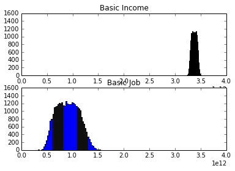

```python
from pylab import *
from scipy.stats import *

num_adults = 227e6
basic_income = 7.25*40*50
labor_force = 154e6
disabled_adults = 21e6
current_wealth_transfers = 3369e9

def jk_rowling(num_non_workers):
    num_of_jk_rowlings = binom(num_non_workers, 1e-7).rvs()
    return num_of_jk_rowlings * 1e9

def basic_income_cost_benefit():
    direct_costs = num_adults * basic_income
    administrative_cost_per_person = norm(250,75)
    non_worker_multiplier = uniform(-0.10, 0.15).rvs()
    non_workers = (num_adults-labor_force-disabled_adults) * (1+non_worker_multiplier)
    marginal_worker_hourly_productivity = norm(10,1)

    administrative_costs = num_adults * administrative_cost_per_person.rvs()
    labor_effect_costs_benefit = -1 * ((num_adults-labor_force-disabled_adults) *
                                       non_worker_multiplier *
                                       (40*52*marginal_worker_hourly_productivity.rvs())
                                       )
    return direct_costs + administrative_costs + labor_effect_costs_benefit - jk_rowling(non_workers)

def basic_job_cost_benefit():
    administrative_cost_per_disabled_person = norm(500,150).rvs()
    administrative_cost_per_worker = norm(5000, 1500).rvs()
    non_worker_multiplier = uniform(-0.20, 0.25).rvs()
    basic_job_hourly_productivity = uniform(0.0, 7.25).rvs()

    disabled_cost = disabled_adults * (basic_income + administrative_cost_per_disabled_person)
    num_basic_workers = ((num_adults - disabled_adults - labor_force) *
                         (1+non_worker_multiplier)
                         )

    basic_worker_cost_benefit = num_basic_workers * (
        basic_income +
        administrative_cost_per_worker -
        40*50*basic_job_hourly_productivity
        )
    return disabled_cost + basic_worker_cost_benefit


N = 1024*32
bi = zeros(shape=(N,), dtype=float)
bj = zeros(shape=(N,), dtype=float)

for k in range(N):
    bi[k] = basic_income_cost_benefit()
    bj[k] = basic_job_cost_benefit()

subplot(211)
width = 4e12
height=50*N/1024

title("Basic Income")
hist(bi, bins=50)
axis([0,width,0,height])

subplot(212)
title("Basic Job")
hist(bj, bins=50)

axis([0,width,0,height])

show()
```

### Our answer:

- A **basic job** has a lower cost / benefit than a basic income, thus given the conditions outlined here it is the preferred solution.

### Bayes' Theorem

- A method to understand the conditional probability of two events
- Bayes' Theorem is: $P(A|B) = \frac{P(B | A)\, P(A)}{P(B)}$
- Here $A$ and $B$ are events
- $P(A)$ and $P(B)$ are the probabilities of $A$ and $B$, and
- $P(A|B)$, the conditional probability, is the probability of $A$ given that $B$ is true.

## Huh?

Let's start over, and put it in English:

- First, we need to distinguish between **tests** and **events**
  - Tests are not the event.
    - We have a cancer test, separate from the event of actually having cancer. We have a test for spam, separate from the event of actually having a spam message.
  - Tests are flawed.
    - Tests detect things that don’t exist (false positive), and miss things that do exist (false negative).
  - Tests give us test probabilities, not the real probabilities.
    - People often consider the test results directly, without considering the errors in the tests.
  - False positives skew results.
    - Suppose you are searching for something really rare (1 in a million). Even with a good test, it’s likely that a positive result is really a false positive on somebody in the 999,999.
  - People prefer natural numbers.
    - Saying “100 in 10,000″ rather than “1%” helps people work through the numbers with fewer errors, especially with multiple percentages (“Of those 100, 80 will test positive” rather than “80% of the 1% will test positive”).

**Bayes’ theorem finds the actual probability of an event from the results of your tests.**

For example, you can:

- **Correct for measurement errors.** If you know the real probabilities and the chance of a false positive and false negative, you can correct for measurement errors.
- **Relate the actual probability to the measured test probability.** Bayes’ theorem lets you relate $P(A|B)$, the chance that an event A happened given the indicator B, and $P(X|A)$, the chance the indicator B happened given that event A occurred. Given mammogram test results and known error rates, you can predict the actual chance of having cancer.

## The Bayesian Approach to Breast Cancer Testing

Let's assume we know the following scenario: * 1% of women have breast cancer (and therefore 99% do not). * 80% of mammograms detect breast cancer when it is there (and therefore 20% miss it). * 9.6% of mammograms detect breast cancer when it’s **not** there (and therefore 90.4% correctly return a negative result)

The Probability Looks like:

|  | Cancer (1%) | No Cancer (99%) |
| --- | --- | --- |
| Positive Test | 80% | 9.6% |
| Negative Test | 20% | 90.4% |

### How do we read it?

- 1% of people have cancer
- If you **already have cancer**, you are in the first column. There’s an 80% chance you will test positive. There’s a 20% chance you will test negative.
- If you **don’t have cancer**, you are in the second column. There’s a 9.6% chance you will test positive, and a 90.4% chance you will test negative.

## How Accurate Is The Test?

- Now suppose you get a positive test result. What are the chances you have cancer? 80%? 99%? 1%?
- Here’s how I think about it:
  - A positive result means we’re somewhere in the top row of our table.
    - Let’s not assume anything — it could be a true positive or a false positive.
- The chances of a true positive = chance you have cancer * chance test caught it = 1% * 80% = .008
- The chances of a false positive = chance you don’t have cancer * chance test caught it anyway = 99% * 9.6% = 0.09504

The probability table now looks like this:

|  | Cancer (1%) | No Cancer (99%) |
| --- | --- | --- |
| Positive Test | True Pos: 1% * 80% | False Pos: 99% * 9.6% |
| Negative Test | False Neg: 1% * 20% | True Neg: 99% * 90.4% |

Remember, the chance of an event is the number of ways it could happen, given all possible outcomes:

$P(event) = \frac{P(desired)}{P(all)}$

The chance of getting a real, positive result is .008. The chance of getting any type of positive result is the chance of a true positive plus the chance of a false positive (.008 + 0.09504 = .10304).

So, our chance of cancer is .008/.10304 = 0.0776, or about 7.8%.

So: a positive mammogram only means you have a **7.8%** chance of cancer, rather than **80%** (the supposed accuracy of the test).

It might seem strange at first but it makes sense:

- The test gives a false positive 10% of the time, so there will be a ton of false positives in any given population.
  - There will be so many false positives, in fact, that most of the positive test results will be wrong.
- Think about it a different way:
  - We start with 100 people.
  - 1 person has cancer.
    - They are highly likely to test positive.
  - Of 99 remaining people - 10 will test positive falsely.
  - So just 1 result in 11 is correct, so there’s a 1/11 chance of having cancer given a positive test.
  - The real number is 7.8% (closer to 1/13, computed above), but we found a reasonable estimate without a calculator.

## Reintroduce the Bayes' Theorem Equation:

Bayes' Theorem is: $P(A|B) = \frac{P(B|A)\, P(A)}{P(B|A) \centerdot P(A) + P(B|\sim A) \centerdot P(\sim A)}$

In the context of the above problem: P(A|B) = Chance of having cancer (A) given a positive test (B). This is what we want to know: How likely is it to have cancer with a positive result? In our case it was 7.8%. P(B|A) = Chance of a positive test (B) given that you had cancer (A). This is the chance of a true positive, 80% in our case. P(A) = Chance of having cancer (1%). P(~A) = Chance of not having cancer (99%). P(B|~A) = Chance of a positive test (B) given that you didn’t have cancer (~A). This is a false positive, 9.6% in our case.

## Solve the cancer test problem with Bayes:

$P(A|B) = \frac{0.80 \centerdot 0.01}{0.8 \centerdot 0.01 + 0.096 \centerdot .99}$

$P(A|B) = \frac{.008}{.10304}$

$P(A|B) = 0.0776 = 0.078 = 7.8%$

## Exercise:

- What is the chance of a false negative (ie, you test negative but actually have cancer?)